# Implementació del projecte de final de màster

Carles Cayuela Linares

2023-12-15

# IMPLEMENTACIÓ DEL PROJECTE

Aquest document forma part de la memòria del Treball de Final de Màster de Ciència de Dades de la UOC. Inclou les tècniques utilitzades per generar el conjunt de dades, la Xarxa Neuronal Artificial i els mapes de previsió del risc resultants de l’aplicació del model desenvolupat.

# GENERACIÓ DEL DATASET

Generar el conjunt de dades ha estat costós. Com s’explica a la memòria, la majoria d’estudis analitzats relacionats amb la previsió del risc d’incendi i machine learning, analitzen les dades meteorològiques a nivell mensual i utilitzen valors agregats.

Per afegir una novetat a aquest projecte, s’ha aprofitat l’API del Servei Meteorològic per poder iterar, i extreure les condicions meteorològiques específiques de cada dia en el qual es va detectar un incendi. Per fer-ho, s’ha generat un *grid* sobre de Catalunya de punts separats entre ells per 200m de distància.

Per a cada punt s’ha extret informació de:

- Altitud
- Pendent
- Orientació
- Coberta del sòl
- Temperatura
- Humitat relativa
- Velocitat del vent
- Si hi ha foc o no

Cadascuna d’aquestes variables prové d’una capa tipus ràster. L’altitud, pendent orientació provenen d’un Model Digital del Terreny descarregat de la web de l’ICGC. Les cobertes del sòl provenen d’un ràster també descarregat de l’ICGC. Les dades meteorològiques s’han generat a partir d’interpolacions de dades puntuals de les estacions meteorlògiques disponibles a l’API del METEOCAT.

L’API del METEOCAT no és d’ús obert a tothom, però com a estudiant he pogut tenir accés de manera gratuita. El Centre Forestal de Catalunya (CREAF) ha desenvolupat una [llibreria](https://emf-creaf.github.io/meteospain/) que permet rebre dades de prediccions i històrics des d’R.

S’han analitzat un total de 561 incendis històrics. Han representat un total de 561 taules amb 802.591 registres cadascuna (corresponents a la informació de les 8 variables per cadascún dels punts en què s’ha dividit el *grid*), en total més de 450 milions de registres. Aquesta informació s’ha organitzat en llistes de taules, com que la capacitat de l’equip amb que s’ha dut a terme el projecte és limitada s’ha hagut de dividir aquesta iteració en 7 fragments.

Finalment, s’ha fet un mostreig estratificat que ha permés obtenir un *dataset* homogeni pel que fa a registres amb foc i registres sense foc.

L’objectiu final és obtenir un model que permeti identificar en quines condicions pot haver-hi foc i en quines no. Per tant, voldrem un model que ens classifiqui bé els casos positius, el casos negatius també, però serem tolerants am els falsos positius, ja que aquests encara que no presentin foc, reuniran les condicions per tenir-ne, i per tant, seran punts potencials per tenir en compte a l’hora de valorar el risc d’incendi.

A continuació es presenta el codi pas per pas. Aquells fragments de codi que són lents, com el loop per obtenir les de dades, apareixen comentats o no s’han evaluat.

```r
# Llibreries:
library(tidyverse)
library(tidyr)
library(sf)
library(raster)
library(ggplot2)
library(stars)
library(terra)
library(dplyr)
library(lubridate)
library(gstat)
library(kableExtra)
library(tibble)
library(meteospain) # per l'API METEOCAT
library(ggpubr)
library(h2o) # Xarxa neuronal
```

## Càrrega de dades

```r
#---- Projecció del projecte: ETRS89 Zone 31
projeccio <- "+proj=utm +zone=31 +ellps=GRS80 +towgs84=0,0,0,0,0,0,0 +units=m +no_defs +type=crs"

#---- Dades
shpCatalunya <- "shp/divisions-administratives-v2r1-catalunya-500000-20230928.shp" # shapefile Catalunya
demCat_path <- "mdt/mdtCatalunya.tif" # Digital elevation Mode Catalunya
incendis <- "shp/incendis/incendis_1989_2022_mod.shp" # shapefile amb l'històric d'incendis
usosSol_path <- "gpkg/usosSolCat.tif"

#---- Àmbit del projecte
catalunya <- read_sf(shpCatalunya)
catalunya <- st_transform(catalunya, crs = projeccio)
```

## Generació del grid de 200x200m

```r
#---- GRID: Definim un GRID que servirà per extreure les dades espaials a una taula:
# grid_spacing <- 200 # Ajustar a 200

#---- Grid de Punts:
# grid_points <- catalunya %>%
#   st_make_grid(what = "centers", cellsize = c(grid_spacing, grid_spacing))

# grid_points <- catalunya %>%
#   st_make_grid(what = "centers", cellsize = c(grid_spacing, grid_spacing))  %>%
#   st_intersection_faster(catalunya)

# QGIS
# grid_points_spatial_sf <- st_as_sf(grid_points)
# st_write(grid_points_spatial_sf, "shp/grid_200.shp")

grid_points_spatial_sf <- st_read("shp/grid_200_clip.shp")
grid_points_spatial_sf <- st_transform(grid_points_spatial_sf, crs = projeccio)
```

A continuació generem una taula que s’anirà omplint amb les dades que extreurem de cada capa.

```r
#---- Crear el DataFrame de SpatialPoints per anar omplint amb les dades:
coords <- st_coordinates(grid_points_spatial_sf)

grid_df <- SpatialPointsDataFrame(
  coords = coords,
  data = data.frame(ID= 1:nrow(grid_points_spatial_sf)),
  proj4string = CRS(projeccio)
)
```

Corregim el format de les dades històriques d’incendis:

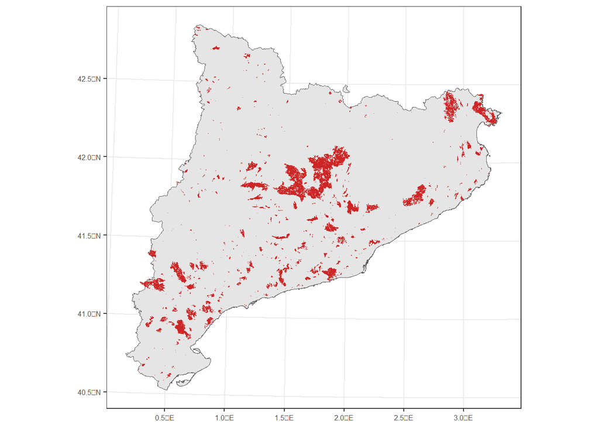

```r
# INCENDIS ###################################################################################

# Llegeix
incendisCat <- st_read(incendis)
incendisCat <- st_zm(incendisCat) #Corregeix geometries
incendisCat <- st_transform(incendisCat, crs = projeccio)

# Càlcul àrea
incendisCat$area <- as.numeric(st_area(incendisCat)/10000) # Àrea en ha

# Representació gràfica edls incendis
ggplot() +
  geom_sf(data = catalunya) +
  geom_sf(data = incendisCat, fill="firebrick3", colour=NA) +
  theme_bw() +
  theme(
    axis.text = element_text(size=6)
  )
```

```r
# Selecció final d'incendis
incendisCat <- incendisCat %>%
  filter(area > 0.1) %>%
  filter(!is.na(DATA_INCEN)) %>%
  mutate(DATA_INCEN = gsub(pattern = "\r\n", replacement = "", DATA_INCEN)) %>%
  mutate(DATA_INCEN = as.Date(lubridate::parse_date_time(DATA_INCEN, c('%d/%m/%Y', '%d/%m/%y')))) %>%
  filter(DATA_INCEN >= as.Date("1993-01-01"))
```

## Dades Geomorfològiques i usos del sòl

```r
# DADES GEOMORFOLÒGIQUES: ########################################

#---- ELEVACIÓ
demCat <- raster(demCat_path)
projection(demCat) <- projeccio

# Retalla raster
demCat_stars <- st_as_stars(demCat)
demCat_crop <- st_crop(demCat_stars, catalunya)


#---- SLOPE
slopeCat <- terrain(demCat, opt="slope", unit="degrees")
slopeCat_crop <- mask(slopeCat, catalunya)

#---- ASPECT
aspectCat <- terrain(demCat, opt="aspect", unit="degrees")
aspectCat_crop <- mask(aspectCat, catalunya)


# USOS DEL SÒL ###############################################################################
usosSol <- raster(usosSol_path)
projection(usosSol) <- projeccio
usosSol_df <- as.data.frame(usosSol, xy=TRUE)
```

Connexió amb l’API del Servei Meteorològic de Catalunya i mapa d’estacions disponibles.

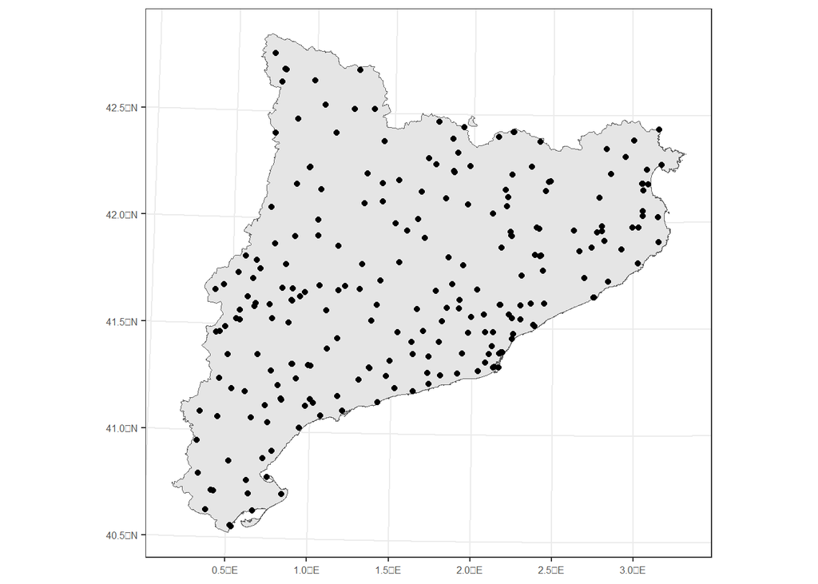

```r
# dies sobre els que caldrà iterar
llistat_dates <- unique(incendisCat$DATA_INCEN)

# API Meteocat
apyKey # Clau facilitada pel METEOCAT (ús personal)

# Mapa estacions:
meteocat_stations <- get_stations_info_from('meteocat', options = meteocat_options(api_key = apyKey))
meteocat_stations_trans <- st_transform(meteocat_stations, crs = projeccio)

ggplot() +
  geom_sf(data=catalunya) +
  geom_sf(data=meteocat_stations_trans) +
  theme_bw() +
  theme(
    axis.text = element_text(size=6)
  )
```

```r
# Bases per fer la interpolació IDW:

grd <- st_bbox(catalunya) %>%
  st_as_stars(dx = 2000) %>% # 2km x 2km
  st_crop(catalunya)
```

Iteració per extreure les dades meteorològiques, geomorfològiques i de coberta del sòl sobre cada punt del grid.

```r
# Inicialització de variables
df_list <- list()
n_list <- 1


# Loop per extreure les dades meteorològiques:
for (data in as.list(llistat_dates[data])) {

  # Incendis data:
  foc <- incendisCat %>%
        filter(DATA_INCEN == data)


  #Extreu dades Meteo

  dadesMeteo <- get_meteo_from('meteocat', options = meteocat_options(resolution = "daily", start_date = data, api_key = apyKey))

  dadesMeteo_sf <- dadesMeteo %>%
    filter(timestamp == data) %>%
    dplyr::select(max_temperature, mean_relative_humidity, mean_wind_speed) %>%
    mutate(max_temperature = as.numeric(max_temperature),
           mean_relative_humidity = as.numeric(mean_relative_humidity),
           mean_wind_speed = as.numeric(mean_wind_speed))


  if (nrow(dadesMeteo_sf) == 0) {

    n_list = n_list + 1

    } else {


  dadesMeteo_sf <- st_transform(dadesMeteo_sf, crs = projeccio)

  dadesMeteo_sf_temp <- filter(dadesMeteo_sf, !is.na(max_temperature))
  dadesMeteo_sf_temp <- dadesMeteo_sf_temp %>% filter(!st_is_empty(.))

  dadesMeteo_sf_rh <- filter(dadesMeteo_sf, !is.na(mean_relative_humidity))
  dadesMeteo_sf_rh <- dadesMeteo_sf_rh %>% filter(!st_is_empty(.))

  dadesMeteo_sf_wind <- filter(dadesMeteo_sf, !is.na(mean_wind_speed))
  dadesMeteo_sf_wind <- dadesMeteo_sf_wind %>% filter(!st_is_empty(.))



  temp <- idw(max_temperature~1, dadesMeteo_sf_temp, grd)
  rh <- idw(mean_relative_humidity~1, dadesMeteo_sf_rh, grd)
  wind <- idw(mean_wind_speed~1, dadesMeteo_sf_wind, grd)

  temp <- as(temp, "Raster")
  rh <- as(rh, "Raster")
  wind <- as(wind, "Raster")


  temp_points <- extract(temp$var1.pred, grid_points_spatial_sf)
  rh_points <- extract(rh$var1.pred, grid_points_spatial_sf)
  wind_points <- extract(wind$var1.pred, grid_points_spatial_sf)

  # Incendis:
  fire_points = st_intersects(grid_points_spatial_sf, foc) # Comprova si interaccionen
  fire_intersects <- lengths(fire_points) > 0


  # Usos del sòl:
  usosSol_points <- extract(usosSol, grid_points_spatial_sf)

  # Geomorfologia:
  elevation_points <- extract(demCat, grid_points_spatial_sf)
  slopeCat_points <- extract(slopeCat, grid_points_spatial_sf)
  aspectCat_points <- extract(aspectCat, grid_points_spatial_sf)



  grid_df$Temperatura <- temp_points
  grid_df$Humitat <- rh_points
  grid_df$Vent <- wind_points
  grid_df$Incendi <- fire_intersects
  grid_df$UsosSol <- usosSol_points
  grid_df$Elevacio <- elevation_points
  grid_df$Pendent <- slopeCat_points
  grid_df$Orientació <- aspectCat_points


  grid_df$Date <- data


  df <- as.data.frame(grid_df)

  df_list[[n_list]] <- df

  n_list = n_list + 1

    }

}


# El procés s'ha fragmentat en 7 iteracions i s'han guardat en un fitxer en local

# saveRDS(df_list, file = "df_list.RDS")
# saveRDS(df_list, file = "df_list_2.RDS")
# saveRDS(df_list, file = "df_list_3.RDS")
# saveRDS(df_list, file = "df_list_4.RDS")
# saveRDS(df_list, file = "df_list_5.RDS")
# saveRDS(df_list, file = "df_list_6.RDS")
# saveRDS(df_list, file = "df_list_7.RDS")
```

## Disseny del Mostreig Estratificat

Per cada llista guardada s’ha extret tots els registres amb foc i de manera aleatòria la mateixa quantita de punts sense foc. Després s’han unnit tots aquests registres en una única taula que ha estat el dataset de treball i s’han barrejat els registres.

```r
# Carrega dades:
taulesLlista <- readRDS("df_list.RDS") # carrega de cada un dels elements


dades <- NULL

for (taula in 1:length(taulesLlista)) {

  n_rows <- length(which(taulesLlista[[taula]]$Incendi == TRUE))

  if (n_rows > 0) {

    samplingStratified <- taulesLlista[[taula]] %>%
      group_by(Incendi) %>%
      sample_n(size=n_rows)

    dades <- rbind(dades, samplingStratified)

  }

}

# dades_1 <- dades
# dades_2 <- dades
# dades_3 <- dades
# dades_4 <- dades
# dades_5 <- dades
# dades_6 <- dades
# dades_7 <- dades

dadesSample <- rbind(dades_1, dades_2, dades_3, dades_4, dades_5, dades_6, dades_7)
dadesSample <- dadesSample[sample(1:nrow(dadesSample)), ] # Dades barrejades

saveRDS(dadesSample, file = "dadesSample.RDS")
```

# IMPLEMENTACIÓ D’UNA XARXA NEURONAL

Després de valorar diferent llibreries i eines per a la implemantació de la Xarxa Neuronal s’ha obtat per utilitzar la llibreria H2O.

H2O és un producte creat per la companyia H2O.ai amb l’objectiu de combinar els principals algoritmes de machine learning i aprenentatge estadístic amb el Big Data. Gràcies a la seva forma de comprimir i emmagatzemar les dades, H2O és capaç de treballar amb milions de registres en un únic ordinador (utilitza tots els seus nuclis) o en un clúster de molts ordinadors. Internament, H2O està escrit en Java i segueix el paradigma Key/Value per emmagatzemar les dades i Map/Reduce pels seus algoritmes. Gràcies a les seves API, és possible accedir a totes les seves funcions des de R, Python o Scala, així com a través d’una interfície web anomenada Flow.

Tot i que l’avantatge principal de H2O davant d’altres eines és la seva escalabilitat, els seus algoritmes són igualment útils quan es treballa amb un volum de dades reduït.

Abans d’ajustar el model ha calgut adequar el dataset:

```r
# Conjunt de dades:
dades <- readRDS("dadesSample.RDS")
# dades <- as.data.frame(dades)

# Preparació del dataset
dataset <- dades %>%
  dplyr::select(Elevacio, Pendent, Orientació, UsosSol, Temperatura, Vent, Humitat, Incendi) %>%
  dplyr::mutate(Incendi = ifelse(Incendi==TRUE, "1", "0"))

dataset <- dataset[complete.cases(dataset),]

dataset$Incendi <- factor(dataset$Incendi, levels = c("0", "1"), labels = c("NoFoc", "Foc"))
colnames(dataset)[3] <- "Orientacio"

summary(dataset)

# write.csv(dataset, "firesDataset.csv", row.names = F)
```

Ara ja es pot iniciar un clúster local amb tots els núclis disponibles

```r
h2o.init(
  ip = "localhost",
  # -1 indica que s'utilitzen tots els cores disponibles
  nthreads = -1,
  # Màxima memoria disponible per al clúster
  max_mem_size = "6g"
)

# S'eliminen les dades del clúster per si havia estat iniciat anteriorment.
h2o.removeAll()
```

Càrrega de dades a H2O

```r
# Càrrega de les dades al clúster.
dades_h2o <- h2o.importFile(
              path   = "firesDataset.csv",
              header = TRUE,
              sep    = ",",
              destination_frame = "datos_h2o"
             )

# Descripció de les dades
h2o.colnames(dades_h2o)
h2o.describe(dades_h2o)
```

Creació dels conjunts de training i test

```r
particions <- h2o.splitFrame(data = dades_h2o, ratios = c(0.8), seed = 123)
dades_train_h2o <- h2o.assign(data = particions[[1]], key = "dades_train_H2O")
dades_test_h2o  <- h2o.assign(data = particions[[2]], key = "dades_test_H2O")

h2o.table(dades_train_h2o$Incendi)
h2o.table(dades_test_h2o$Incendi)

# h2o.table(dades_train_h2o$Incendi)/h2o.nrow(dades_train_h2o)
# h2o.table(dades_test_h2o$Incendi)/h2o.nrow(dades_test_h2o)
```

Disseny del model

```r
# Hiperparàmetres a comparar
hiperparametres <- list(hidden = list(c(10), c(10,10), c(20), c(50), c(50,50), c(80), c(100,100)))
grid_dl <- h2o.grid(
              # Algoritme
              algorithm = "deeplearning",
              activation = "RectifierWithDropout",
              epochs = 500,
              # Variable resposta i predictors
              y = "Incendi",
              x = c("Elevacio", "Pendent", "Orientacio", "UsosSol", "Temperatura", "Vent", "Humitat"),
              # Dades d'entrenament.
              training_frame = dades_train_h2o,
              shuffle_training_data = FALSE,
              # Dades de validació
              validation_frame = dades_test_h2o,
              # Preprocessat
              standardize = TRUE,
              missing_values_handling = "Skip",
              # Detenció temprana
              stopping_rounds = 3,
              stopping_metric = "AUC",
              stopping_tolerance = 0.01,
              # Hiperparàmetres optimitzats
              hyper_params = hiperparametres,
              # Regularización
              l1 = 1e-5,
              l2 = 1e-5,
              # Tipus de cerca
              search_criteria = list(strategy = "Cartesian"),
              seed = 123,
              grid_id = "grid_dl"
          )
```

Comparativa de models

```r
# Es mostren els resultats dels models endreçats de major a menor AUC.
resultats_grid <- h2o.getGrid(
                     grid_id = "grid_dl",
                     sort_by = "auc",
                     decreasing = TRUE
                   )

compara <- data.frame(resultats_grid@summary_table) %>% dplyr::select(-model_ids)
compara
```

Comprovem algunes mètriques

Error de classificació

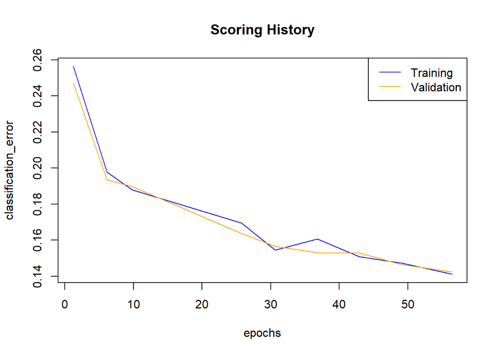

```r
model_dl_final <- h2o.getModel(resultats_grid@model_ids[[1]])
plot(model_dl_final, timestep = "epochs", metric = "classification_error")
```

Matriu de confussió

```r
conf_matrix <- h2o.confusionMatrix(model_dl_final, newdata=dades_test_h2o)
conf_matrix
```

[output not shown]

Corba ROC

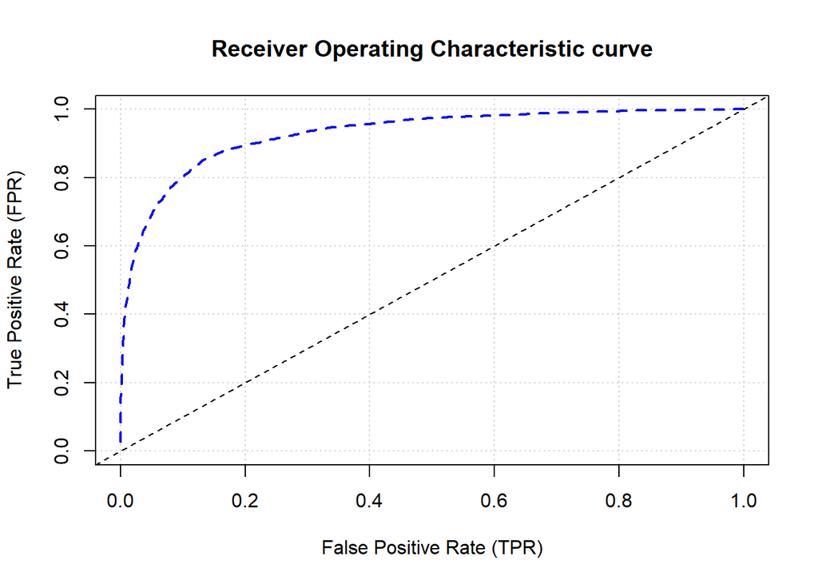

```r
performance <- h2o.performance(model_dl_final, newdata = dades_test_h2o)
plot(performance, type='roc')
```

*# GENERACIÓ D’UN MAPA DE PREVISIÓ DEL RISC D’INCENDI*

Obtenció d’un conjunt per predir si hi haurà risc d’incendi.

```r
#=======================================================#
# Extracció de dades per una data concreta: 15/12/2023
#=======================================================#

apyKey <- "quhbuOonNB25EZimVII7h5tGGYNcgHCX3Znp9Hp1"
# Grid per a la IDW:
grd <- st_bbox(catalunya) %>%
  st_as_stars(dx = 2000) %>% # 2km x 2km
  st_crop(catalunya)

data <- as.Date("2023-12-15")

# Carrega capes:
demCat <- readRDS(file = "demCat.RDS")
slopeCat <- readRDS(file = "slopeCat.RDS")
aspectCat <- readRDS(file = "aspectCat.RDS")
usosSol <- readRDS(file = "usosSol.RDS")


# Incendis data:
# foc <- incendisCat %>%
#       filter(DATA_INCEN == data)

# Extreu dades Meteo
dadesMeteo <- get_meteo_from('meteocat', options = meteocat_options(resolution = "daily", start_date = data, api_key = apyKey))

dadesMeteo_sf <- dadesMeteo %>%
  filter(timestamp == data) %>%
  dplyr::select(max_temperature, mean_relative_humidity, mean_wind_speed) %>%
  mutate(max_temperature = as.numeric(max_temperature),
         mean_relative_humidity = as.numeric(mean_relative_humidity),
         mean_wind_speed = as.numeric(mean_wind_speed))


dadesMeteo_sf <- st_transform(dadesMeteo_sf, crs = projeccio)

dadesMeteo_sf_temp <- filter(dadesMeteo_sf, !is.na(max_temperature))
dadesMeteo_sf_temp <- dadesMeteo_sf_temp %>% filter(!st_is_empty(.))

dadesMeteo_sf_rh <- filter(dadesMeteo_sf, !is.na(mean_relative_humidity))
dadesMeteo_sf_rh <- dadesMeteo_sf_rh %>% filter(!st_is_empty(.))

dadesMeteo_sf_wind <- filter(dadesMeteo_sf, !is.na(mean_wind_speed))
dadesMeteo_sf_wind <- dadesMeteo_sf_wind %>% filter(!st_is_empty(.))



temp <- idw(max_temperature~1, dadesMeteo_sf_temp, grd)
rh <- idw(mean_relative_humidity~1, dadesMeteo_sf_rh, grd)
wind <- idw(mean_wind_speed~1, dadesMeteo_sf_wind, grd)

temp <- as(temp, "Raster")
rh <- as(rh, "Raster")
wind <- as(wind, "Raster")


detach("package:tidyr", unload=TRUE) # Genera un error tenir aquesta llibreria carregada
# .rs.unloadPackage("tidyr") # Genera un error tenir aquesta llibreria carregada

temp_points <- extract(temp$var1.pred, grid_points_spatial_sf)
rh_points <- extract(rh$var1.pred, grid_points_spatial_sf)
wind_points <- extract(wind$var1.pred, grid_points_spatial_sf)

# Incendis:
# fire_points = st_intersects(grid_points_spatial_sf, foc) # Comprova si interaccionen
# fire_intersects <- lengths(fire_points) > 0


# Usos del sòl:
usosSol_points <- extract(usosSol, grid_points_spatial_sf)

# Geomorfologia:
elevation_points <- extract(demCat, grid_points_spatial_sf)
slopeCat_points <- extract(slopeCat, grid_points_spatial_sf)
aspectCat_points <- extract(aspectCat, grid_points_spatial_sf)

# Omple la taula
grid_df$Date <- data
grid_df$Temperatura <- temp_points
grid_df$Humitat <- rh_points
grid_df$Vent <- wind_points
grid_df$UsosSol <- usosSol_points
grid_df$Elevacio <- elevation_points
grid_df$Pendent <- slopeCat_points
grid_df$Orientació <- aspectCat_points
# grid_df$Incendi <- fire_intersects

df <- as.data.frame(grid_df)
```

Aplicació del model sobre les dades

```r
#=======================================================#
# Aplicació del model sobre les dades
#=======================================================#

library(tidyr)

dades_perill <- df %>%
  dplyr::select(Elevacio, Pendent, Orientació, UsosSol, Temperatura, Vent, Humitat, X, Y) %>%
  drop_na

# Extraiem les coordenades:
coords <- dades_perill[,c("X", "Y")]

dades_perill <- dades_perill[,-c(8:9)]

# Predicció
dades_perill_pred <- h2o.predict(model_dl_final, newdata = as.h2o(dades_perill)[-1,]) # Cal treure la primera fila, la capçalera


y_pred <- as.vector(ifelse(dades_perill_pred$predict == 'NoFoc', 0, 1))
# y_test_set <- ifelse(dades_dia$Incendi == 'NoFoc', 0, 1)
# cm <- table(y_test_set, y_pred)
# cm
```

Generem el mapa. El model ens dona punts amb risc d’incendi i punts de no risc. Per establir una categorització del risc s’ha establert una classificació en funció de la densitat de punts amb risc en una àrea de 2.5km x 2.5km.

Els mapes resultants es poden comparar amb els que es pengen a la web del Departament d’Acció Climàtica, Alimentació i Agenda Rural https://agricultura.gencat.cat/ca/ambits/medi-natural/incendis-forestals/mapes/mapa-perill-incendi/index.html

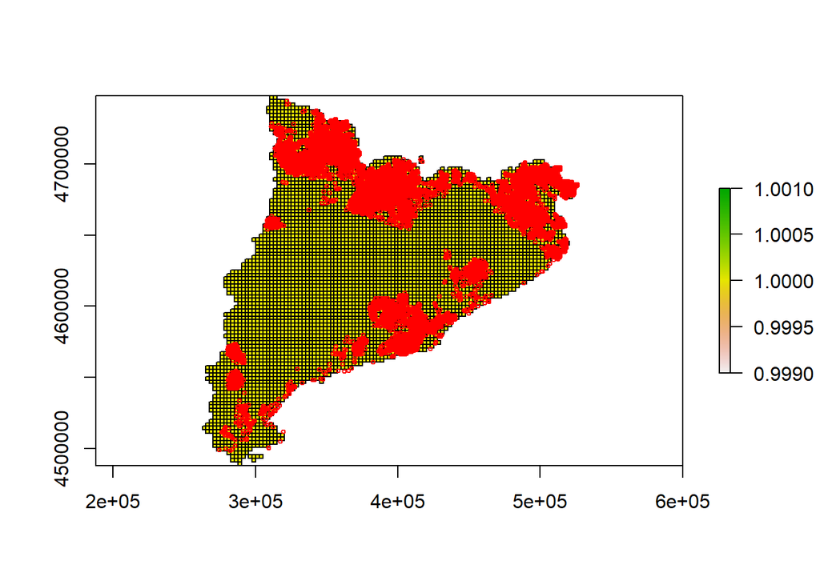

```r
#=======================================================#
# Mapa de perill d'incendi
#=======================================================#

risc <- as.data.frame(y_pred)
risc_incendi_Spatial <- SpatialPointsDataFrame(coords = coords, data = risc,
                               proj4string = CRS("+proj=utm +zone=31 +ellps=GRS80 +towgs84=0,0,0,0,0,0,0 +units=m +no_defs +type=crs"))
risc_incendi_filter <- risc_incendi_Spatial %>%
  subset(y_pred ==1 )

# Raster de 5x5
r <- raster(catalunya)
res(r) <- 2500

r <- rasterize(catalunya, r)
quads <- as(r, 'SpatialPolygons')

# sf_object <- st_as_sf(quads)
# st_write(sf_object, "shp/quads_2500.shp")

# Mapa de punts de risc
{plot(r)
plot(quads, add=TRUE)
points(risc_incendi_filter, col='red', cex=.5)}
```

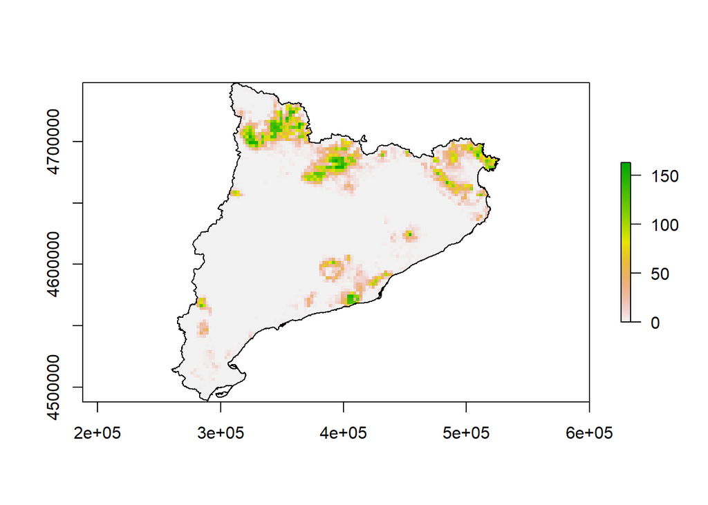

```r
# Mapa de punts per píxel
num_risc <- rasterize(coordinates(risc_incendi_filter), r, fun='count', background=0)

# {plot(num_risc)
# plot(catalunya, add=TRUE)}

num_risc_mask <- mask(num_risc, r)
{plot(num_risc_mask)
plot(catalunya, add=TRUE, col=NA)}
```

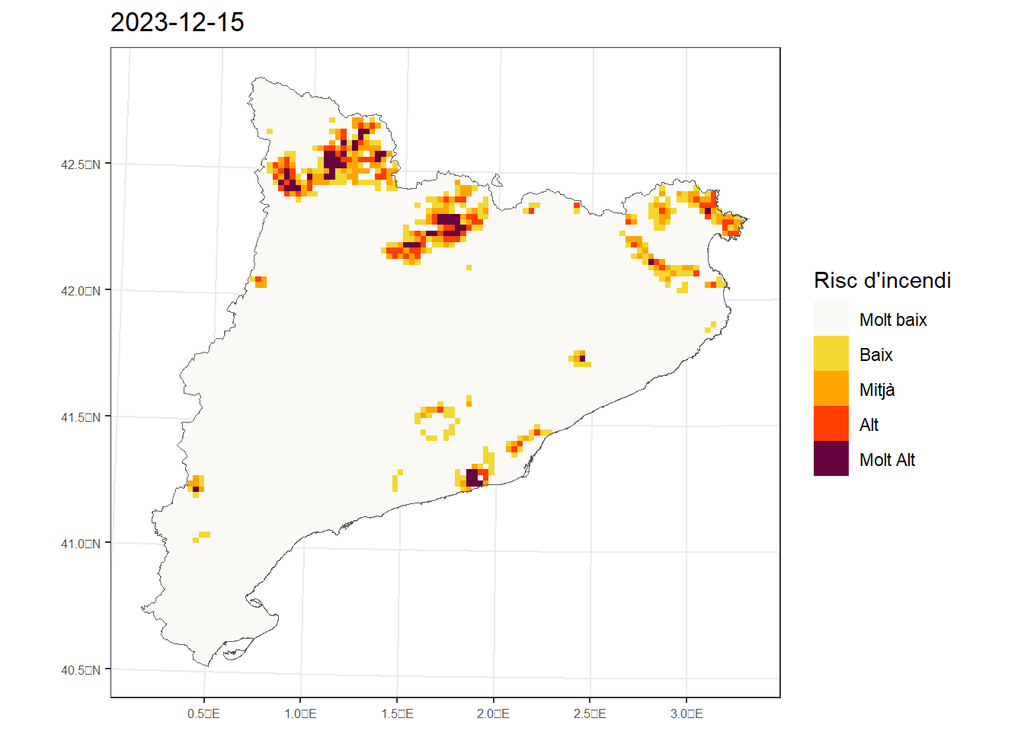

```r
# cReclassificació 156 max num punts per quad
reclass_df <- c(0, 31.2, 0,
                31.2, 62.4, 1,
                62.4, 93.6, 2,
                93.6, 124.8, 3,
                124.8, Inf, 4
                )

reclass_m <- matrix(reclass_df,
                    ncol = 3,
                    byrow = TRUE)

num_risc_mask_reclass <- reclassify(num_risc_mask, reclass_m)


# GGPLOT:
num_risc_mask_reclass_df <- as.data.frame(num_risc_mask_reclass, xy=TRUE)


mapa_perill <- ggplot() +
  geom_raster(data = num_risc_mask_reclass_df, aes(x=x, y=y, fill=as.factor(layer))) +
  geom_sf(data = catalunya, fill=NA) +
  scale_fill_manual(name = "Risc d'incendi",
                    values=c("#FAF9F6", "#f4d730", "#FFA500", "#ff3e00", "#66023c"),
                    # values=c("#ffffff", "#e9cec8", "#f4d730", "#FFA500", "#ff3e00", "#66023c"),
                    # values=c("#FAF9F6", "#e9cec8", "#f4d730", "#FFA500", "#ff3e00"),
                    labels=c("Molt baix","Baix", "Mitjà", "Alt", "Molt Alt"),
                    na.value=NA, na.translate = F) +
  ggtitle(data) +
  theme_bw() +
  theme(
    axis.text = element_text(size=6),
    axis.title = element_blank()
    )

mapa_perill
```